# Randomness and Sampling

Last updated: 2017-01-24

## Notes

## Readings

## Randomness

A repeatable process is random if its outcome is

- unpredictable in the short run
- predictable in the long run

e.g., coin flipping (fair coin)

- We don't know what the result of a single flip will be
- We do know what the long run probability of heads will be

## Random sampling

Assumptions of most statistical analyses

1. **Equal chance**: Each member of a population has an equal chance of being included in the sample
2. **Independence**: No member that is chosen influences the others that are chosen *or* their outcomes (e.g., trait values)

Goals:

- Minimize bias
- Allow an estimation of sampling error (an important concept)

## IID

IID: Independent and identically distributed

- All observations are independent of one another
- All observations come from the same underlying probability distribution (normal, etc.)

Standard assumption of most statistical tests.

## Normal (Gaussian)

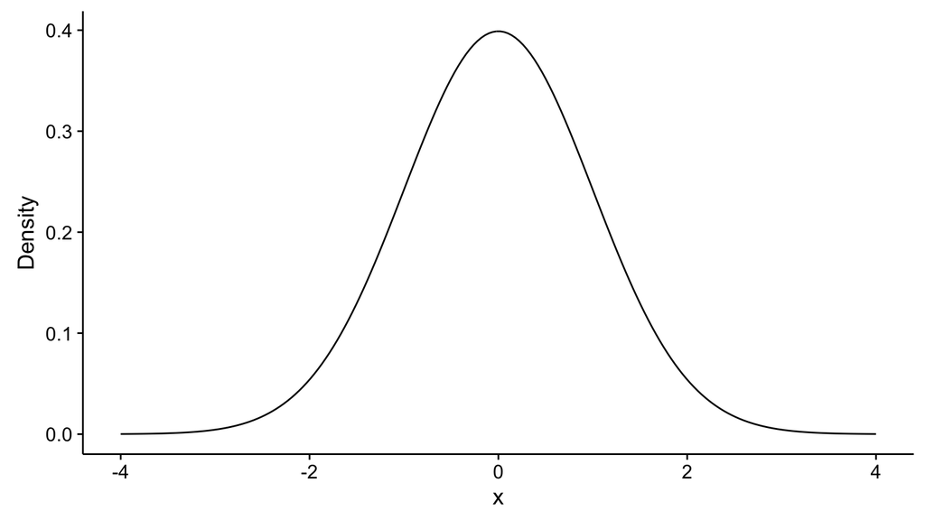

## Binomial

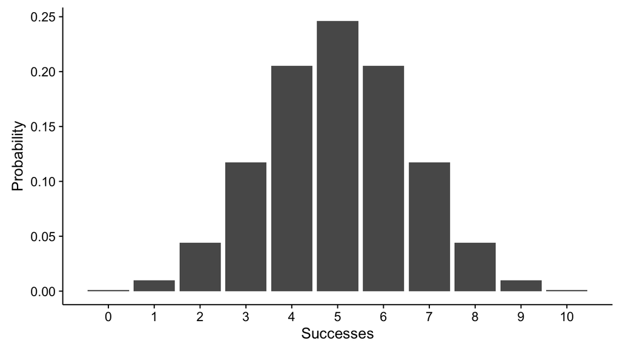

\(Pr[success] = 0.5\); Trial size = \(10\).

## Poisson

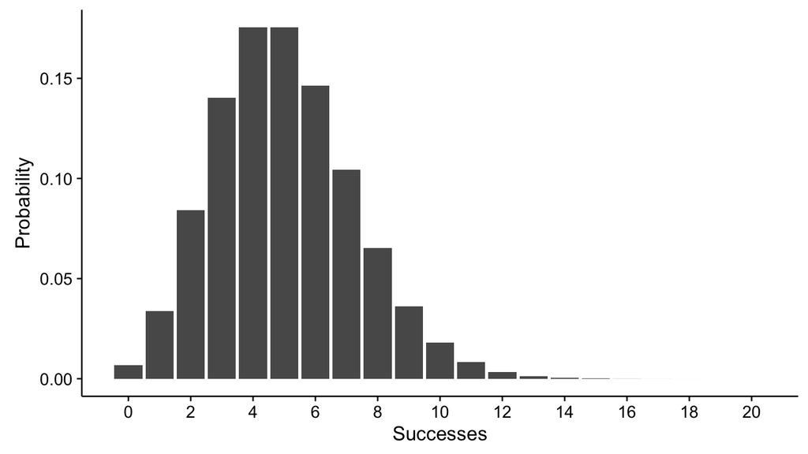

\(\lambda = 5\)

## Random sampling

Randomly select 20 trees (left) or randomly select 20 square quadrats with 0 or more trees (right).

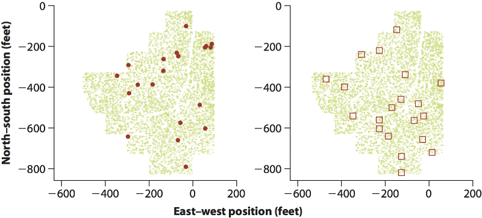

How realistic is this?